# Kontrakty terminowe - generatory rozkładów, modelowanie roszczeń i wycena opcji.

Projekt na zajęcia Kontrakty Terminowe

Szymon Pawłowski

2022-02-01

# 1 Generator liczb pseudolosowych z rozkładu jednostajnego metodą liniowej kongruencji

## 1.1 Wprowadzenie

Generatorem liczb pseudolosowych nazywamy procedurę generującą zmienne losowe $U_1, U_2, ...$, takie że:

1. $\forall_{i}\quad U_i \sim U(0,1)$,
2. zmienne losowe $U_i$ są wzajemnie niezależne.

Przy czym druga własność jest ważna z racji, iż implikuje brak korelacji pomiędzy wszystkimi parami zmiennych losowych oraz fakt, że zmienna losowa $U_i$ nie powinna być przewidywalna na podstawie pozostałych zmiennych losowych $U_1, ..., U_{i-1}$.

Taki generator liczb pseudolosowych dostarcza skończony ciąg liczb $u_1, u_2, ..., u_K$ na przedziale jednostkowym, który przeważnie są zależne od wartości parametrów generatora podanych przez użytkownika. Każdy taki ciąg stanowi zbiór możliwych wyników niezależnych zmiennych $U_1, ..., U_K$, przy czym niewielkie, względem $K$, podzbiory tych ciągów powinny być trudne do rozróżnienia od realizacji ciągu zmiennych losowych z rozkładu jednostajnego.

Efektywny generator zwraca wartości, które są spójne z powyższymi warunkami (1) oraz (2). Przy odpowiednio dużym $K$, ułamek wygenerowanych wartości z podprzedziału jednostkowego powinien być w przybliżeniu równy długości tego podprzedziału. Co więcej, niezależność sugeruje, że nie powinien być dostrzegalny żaden wzorzec przy wykreślaniu wygenerowanych liczb.

## 1.2 Przykładowy generator

Jednym z przykładowych generatorów liczb pseudolosowych jest generator kongruencji liniowej. Można go wyrazić w następujący sposób
$$x_{i+1} = ax_i \ mod(m),$$
$$u_{i+1} = \frac{x_{i+1}}{m}.$$
W tym przypadku parametr $a$ nazywany jest *mnożnikiem*, natomiast $m$ parametrem *modulo*. Są to stałe, które determinują generowane wartości przy podaniu dodatkowej wartości inicjacyjnej (*ziarna*) $x_0$. Ziarno jest liczbą całkowitą określoną przez użytkownika o wartości leżącej między $1$, a $m-1$.

Operacja $y \ mod(m)$ możemy zapisać w inny sposób
$$y \ mod(m) = y - \lfloor \frac{y}{m} \rfloor \space m,$$
gdzie $\lfloor x \rfloor$ jest najwyższą liczbą całkowitą mniejszą bądź równą $x$. Jak można zauważyć, operacja modulo zawsze zwróci wartość między $0$, a $m-1$. Stąd zwracane przez generator wartości $u_i$ zawsze będą leżały pomiędzy $0$, a $(m-1)/m$, a w szczególności, będą leżały na przedziale jednostkowym.

Należy także zwrócić uwagę na termin *pełnego okresu*. Liniowy generator kongruencji osiąga pełny okres, gdy zwraca $m-1$ różnych wartości przed powtórzeniem jakiejkolwiek z nich. W praktyce oczekuje się wygenerowania ogromnej liczby różnych wartości (np. $10$ mln) przed wystąpieniem jakiekolwiek powtórzenia. Aby uzyskać taki rezultat, **nie wystarczy** ustawić parametr $m$ o wysokiej wartości, ponieważ słabe dobranie parametru $a$ może spowodować wygenerowanie liczb o krótkich okresach.

## 1.3 Ogólne zasady konstrukcji generatora liczb pseudolosowych

Przy konstrukcji generatora liczb pseudolosowych należy rozważyć następujące aspekty:

1. **Długość okresu**, a więc czas do powtórzenia wartości. Z reguły im dłuższy okres tym lepiej, a więc oczekuje się generatora, który wyprodukuje jak najwięcej różnych wartości przed wystąpieniem powtórzenia. Dla generatora liniowej kongruencji z modulo $m$ okres wynosi $m-1$. Taki generator osiąga **pełny okres**, gdy odstępy między poszczególnymi wartościami $u_i$ są długości $1/m$, więc im wyższa wartość $m$ tym bardziej wygenerowane wartości będą przybliżały rozkład jednostajny.
2. **Reprodukowalność**, gdyż istotnym jest często możliwość odtworzenia symulacji przy użyciu tych samych parametrów i uzyskaniu takich samych wartości. W przypadku generatora liniowej kongruencji (lub innego w ogólnej postaci) otrzymujemy taki efekt ustawiając ziarno $x_0$.
3. **Prędkość**, ponieważ generator liczb pseudolosowych może mieć za zadanie wyprodukowanie tysiące bądź więcej wartości w pojedynczej symulacji należy zadbać o czas procesowania takiej sytuacji.
4. **Przenośność** czyli produkowanie takich samych ciągów wygenerowanych wartości na wszystkich platformach komputerowych. W przypadku generatora liniowej kongruencji występuje niekiedy problem z różnym podejściem do zaokrąglania wartości przez co można uzyskać odmienne rezultaty.
5. **Losowość** jest najważniejszym aspektem, który jest najtrudniejszy do zapewnienia. W praktyce do zapewnienia losowości stosuje się dwa podejścia: teoretyczne własności oraz testy statystyczne.

## 1.4 Generator kongruencji liniowej

Generator kongruencji liniowej można przedstawić w ogólnej postaci
$$x_{i+1} = (ax_i + c) \ mod(m)$$
$$u_{i+1} = x_{i+1}/m$$
. Przy czym wartości $a$, $m$ oraz $c$ muszą być liczbami całkowitymi. Co więcej, istnieją pewne warunki, które zapewniają o pełnej okresowości generatora (czyli sytuacji, gdy z dowolnego ziarna $x_o$ ilość różnych wartości wygenerowanych wynosi $m-1$). Tak więc, gdy $c \neq 0$ należy aby:

1. $c$ i $m$ były relatywnie pierwsze, a więc aby ich największym wspólnym dzielnikiem było $1$;
2. każda pierwsza liczba, która dzieli $m$, dzieliła również $a-1$;
3. liczba $a-1$ była podzielna przez $4$, jeśli $m$ jest.

Powyższe warunki implikują fakt, że jeśli $m$ jest pewną potęgą $2$ to generator ma pełny okres, gdy $c$ jest nieparzyste oraz $a=4n + 1$ dla pewnej liczby całkowitej $n$.

Z drugiej strony, gdy $c=0$ i $m$ jest liczbą pierwszą, pełen okres jest osiągnięty z dowolnego $x_0$, jeśli:

1. $a^{m-1} - 1$ nie jest wielokrotnością $m$;
2. $a^j - 1$ nie jest wielokrotnością $m$ dla $j = 1, ..., m-2$.

Taką liczbę $a$ nazywamy **pierwiastkiem pierwotnym** liczby $m$. Można zauważyć, że w takim wypadku ciąg $\{x_i\}$ przybiera postać
$$x_0,\ ax_0,\ a^2x_0, \ a^3x_0,\ ..., \ (mod(m)).$$
Wówczas, gdy $x_0 \neq 0$ to wszystkie wyrazy $x_i$ również są niezerowe. Co więcej, generator z parametrem $c \neq 0$ jest wolniejszy od tego z parametrem zerowym, więc zwyczajowo przyjmuje się parametr $c=0$. Wówczas należy dobrać za $m$ liczbę pierwszą, aby umożliwić konstrukcje generatora o pełnym okresie, poprzez proste znalezienie pierwiastków pierwotnych $m$.

Poniżej przykładowa funkcja przyjmująca postać generatora liniowej kongruencji, gdzie parametr $n$ określa długość wektora wygenerowanych wartości, a pozostałe parametry są analogiczne do tych przedstawionych w teorii.

```r
lcgen <- function(n, m, a, c, x){

  gen <- vector(length = n)

  for (i in 1:n){
    x <- (a * x + c) %% m
    gen[i] <- x/m
  }

  return(gen)
}
```

Sprawdźmy działanie zaimplementowanego generatora dla pewnych, niewielkich wartości trzymając się podanych założeń. Aby ułatwić ich sprawdzanie zaimplementujemy dodatkowe funkcje, w tym:

1. funkcja sprawdzająca czy pewne dwie liczby są względnie pierwsze:

```r
gcd <- function(x,y) {
  r <- x%%y;
  return(ifelse(r, gcd(y, r), y))
}
```

2. funkcja sprawdzająca czy każda pierwsza liczba dzieląca pewną liczbę $x$, dzieli także $y$:

```r
prime_division <- function(x,y){
  is_prime <- function(n) n == 2L || all(n %% 2L:max(2,floor(sqrt(n))) != 0)

  div <- c(1:(y-1))
  divisors <- div[x %% div == 0]

  primes <- c()
  for (i in 1:length(divisors)){
    if (is_prime(divisors[i])==TRUE){
      if ((y-1) %% divisors[i] == 0){

        primes <- c(primes, TRUE)

      } else {
        print(divisors[i])
        primes <- c(primes, FALSE)
      }
    }
  }
  return(primes)

 1092 %% 2
}
```

3. funkcja sprawdzająca podzielność przez $4$:

```r
four_division <- function(x,y){
  if (((x %% 4 == 0) & ((y-1) %% 4 == 0)) | ((x %% 4 != 0) & ((y-1) %% 4 != 0))){
    return(TRUE)
  } else {
    return(FALSE)
  }
}
```

4. funkcja sprawdzająca czy dana liczba $x$ nie jest wielokrotnością liczby $y$:

```r
multiplication <- function(x,y){
  if (y %% (x^(y-1)) != 0){
    return(TRUE)
  } else {
    return(FALSE)
  }
}
```

5. funkcja sprawdzająca czy dana liczba $x$ nie jest wielokrotnością liczby $y$ dla różnych wartości wykładników potęg:

```r
multi_multiplication <- function(x,y){
  info <- c()
  for (i in 1:(x-2)){
    if (y %% (x^i - 1) == 0){
      info <- c(info, FALSE)
    } else {
      info <- c(info, TRUE)
    }
  }
  return(info)
}
```

Przy ich użyciu konstruujemy ogólną funkcję sprawdzającą poprawność założeń.

```r
check_assumptions <- function(m,a,c){
  if (c != 0){
    if (gcd(c,m) == 1){
      if (all(prime_division(m, a))==TRUE){
        if (four_division(m, a)==TRUE){
          return("Założenia spełnione!")
        }
        else{
          return("Błąd! Liczba m podzielna przez 4, ale (a-1) nie jest!")
        }
      } else {
        return("Błąd! Nie każda pierwsza liczba dzieląca m dzieli też a-1!")
      }
    } else {
      return("Błąd! Liczby c i m nie są względnie pierwsze!")
    }
  } else if (c == 0){
    if (multiplication(m, a)==TRUE){
      if (all(multi_multiplication(m,a))==TRUE){
        return("Założenia spełnione!")
      } else {
        return("Błąd! Liczba a^j - 1 jest wielokrotnością m dla pewnego j!")
      }
    } else {
      return("Błąd! Liczba a^(m-1) jest wielokrotnością m!")
    }
  } else {
    return("Przypadek nie został obsłużony!")
  }
}
```

Mając zdefiniowane narzędzia do sprawdzania poprawności założeń możemy przetestować generator dla pewnych wartości. Rozpocznijmy od generowania $n=50$ wartości przy ziarnie $x_0=1$ z przyjętymi parametrami
$$m = 53, \quad a = 20, \quad c = 0.$$

```r
check_assumptions(m=53, a=20, c=0)
```

```
## [1] "Założenia spełnione!"
```

Widzimy, że przyjęte parametry spełniają założenia, więc teraz wygenerujmy parę liczb.

```r
lcgen(50, 53, 20, 0, 1)
```

```
##  [1] 0.37735849 0.54716981 0.94339623 0.86792453 0.35849057 0.16981132
##  [7] 0.39622642 0.92452830 0.49056604 0.81132075 0.22641509 0.52830189
## [13] 0.56603774 0.32075472 0.41509434 0.30188679 0.03773585 0.75471698
## [19] 0.09433962 0.88679245 0.73584906 0.71698113 0.33962264 0.79245283
## [25] 0.84905660 0.98113208 0.62264151 0.45283019 0.05660377 0.13207547
## [31] 0.64150943 0.83018868 0.60377358 0.07547170 0.50943396 0.18867925
## [37] 0.77358491 0.47169811 0.43396226 0.67924528 0.58490566 0.69811321
## [43] 0.96226415 0.24528302 0.90566038 0.11320755 0.26415094 0.28301887
## [49] 0.66037736 0.20754717
```

Rzeczywiście otrzymaliśmy wygenerowane wartości z przedziału jednostkowego, które się nie powtarzają. Zgodnie z przedstawioną teorią, zmiana $n$ na $n=53$ powinna ukazać nam już pierwsze powtórzenie, jako że założenia pełnej okresowości zostały spełnione.

```r
lcgen(53, 53, 20, 0, 1)
```

```
##  [1] 0.37735849 0.54716981 0.94339623 0.86792453 0.35849057 0.16981132
##  [7] 0.39622642 0.92452830 0.49056604 0.81132075 0.22641509 0.52830189
## [13] 0.56603774 0.32075472 0.41509434 0.30188679 0.03773585 0.75471698
## [19] 0.09433962 0.88679245 0.73584906 0.71698113 0.33962264 0.79245283
## [25] 0.84905660 0.98113208 0.62264151 0.45283019 0.05660377 0.13207547
## [31] 0.64150943 0.83018868 0.60377358 0.07547170 0.50943396 0.18867925
## [37] 0.77358491 0.47169811 0.43396226 0.67924528 0.58490566 0.69811321
## [43] 0.96226415 0.24528302 0.90566038 0.11320755 0.26415094 0.28301887
## [49] 0.66037736 0.20754717 0.15094340 0.01886792 0.37735849
```

Jak widać, ostatnia wartość jest już kolejną iteracją całego okresu. Sprawdźmy działanie dla jeszcze mniejszych wartości, wybierając
$$m=7, \quad a=2, \quad c=0.$$

```r
check_assumptions(m=7, a=2, c=0)
```

```
## [1] "Założenia spełnione!"
```

```r
lcgen(50, 7, 2, 0, 1)
```

```
##  [1] 0.2857143 0.5714286 0.1428571 0.2857143 0.5714286 0.1428571 0.2857143
##  [8] 0.5714286 0.1428571 0.2857143 0.5714286 0.1428571 0.2857143 0.5714286
## [15] 0.1428571 0.2857143 0.5714286 0.1428571 0.2857143 0.5714286 0.1428571
## [22] 0.2857143 0.5714286 0.1428571 0.2857143 0.5714286 0.1428571 0.2857143
## [29] 0.5714286 0.1428571 0.2857143 0.5714286 0.1428571 0.2857143 0.5714286
## [36] 0.1428571 0.2857143 0.5714286 0.1428571 0.2857143 0.5714286 0.1428571
## [43] 0.2857143 0.5714286 0.1428571 0.2857143 0.5714286 0.1428571 0.2857143
## [50] 0.5714286
```

Przy takich wartościach parametrów okres oczywiście ma o wiele mniejszą długość, zatem ilość powtórzeń przy $50$ wygenerowanych wartościach będzie większa. Sprawdźmy teraz sytuację dla większych wartości parametrów oraz $c \neq 0$ i weźmy pod uwagę
$$m = 86436, \quad a = 1093, \quad c = 18257.$$

```r
check_assumptions(m=86436, a=1093, c=18257)
```

```
## [1] "Założenia spełnione!"
```

```r
lcgen(50, 86436, 1093, 18257, 1)
```

```
##  [1] 0.2238650562 0.8957263177 0.2400851497 0.6242884909 0.5585404230
##  [6] 0.6959021704 0.8322921005 0.9064857235 0.0001156925 0.3376718034
## [11] 0.2865009950 0.3568073488 0.2016520894 0.6169535842 0.5414873432
## [16] 0.0568860197 0.3876394095 0.9010944514 0.1074552270 0.6597829608
## [21] 0.3539960202 0.1288699153 0.0660372993 0.3899879680 0.4680688602
## [26] 0.8104840576 0.0702947846 0.0434194086 0.6686334398 0.0275695312
## [31] 0.3447174788 0.9874242214 0.4658938405 0.4331875607 0.6852237494
## [36] 0.1607779166 0.9414827155 0.2518279421 0.4591605350 0.0736845759
## [41] 0.7484612893 0.2794090425 0.6053033458 0.8077768522 0.1113193577
## [46] 0.8832778009 0.6338562636 0.0161159702 0.8259752881 0.0022097274
```

Ponownie zmieńmy parametry na
$$m = 2^{11} +1, \quad a = 64, \quad c=73.$$

```r
check_assumptions(m=(2^11+1), a=64, c=73)
```

```
## [1] "Założenia spełnione!"
```

```r
lcgen(50, (2^11 + 1), 64, 73, 1)
```

```
##  [1] 0.0668618838 0.3147877013 0.1820400195 0.6861883846 0.9516837482
##  [6] 0.9433870181 0.4123962909 0.4289897511 0.4909712055 0.4577842850
## [11] 0.3338213763 0.4001952172 0.6481210347 0.5153733529 0.0195217179
## [16] 0.2850170815 0.2767203514 0.7457296242 0.7623230844 0.8243045388
## [21] 0.7911176184 0.6671547096 0.7335285505 0.9814543680 0.8487066862
## [26] 0.3528550512 0.6183504148 0.6100536847 0.0790629575 0.0956564178
## [31] 0.1576378721 0.1244509517 0.0004880429 0.0668618838 0.3147877013
## [36] 0.1820400195 0.6861883846 0.9516837482 0.9433870181 0.4123962909
## [41] 0.4289897511 0.4909712055 0.4577842850 0.3338213763 0.4001952172
## [46] 0.6481210347 0.5153733529 0.0195217179 0.2850170815 0.2767203514
```

```r
check_assumptions(m=8, a=2, c=1)
```

```
## [1] "Błąd! Liczba m podzielna przez 4, ale (a-1) nie jest!"
```

```r
lcgen(50, 8, 2, 1, 1)
```

```
##  [1] 0.375 0.875 0.875 0.875 0.875 0.875 0.875 0.875 0.875 0.875 0.875 0.875
## [13] 0.875 0.875 0.875 0.875 0.875 0.875 0.875 0.875 0.875 0.875 0.875 0.875
## [25] 0.875 0.875 0.875 0.875 0.875 0.875 0.875 0.875 0.875 0.875 0.875 0.875
## [37] 0.875 0.875 0.875 0.875 0.875 0.875 0.875 0.875 0.875 0.875 0.875 0.875
## [49] 0.875 0.875
```

Nie zostało spełnione założenie o podzielności $a-1$ przez 4, gdy $m$ jest podzielna. Możemy zauważyć, że wygenerowały zostały zaledwie dwie różne wartości, gdzie w tym przypadku oczekiwalibyśmy ich siedem. Zmieńmy, więc i podstawmy $a=4$, aby było ono podzielne przez 4.

```r
check_assumptions(m=8, a=4, c=1)
```

```
## [1] 2
```

```
## [1] "Błąd! Nie każda pierwsza liczba dzieląca m dzieli też a-1!"
```

```r
lcgen(50, 8, 4, 1, 1)
```

```
##  [1] 0.625 0.625 0.625 0.625 0.625 0.625 0.625 0.625 0.625 0.625 0.625 0.625
## [13] 0.625 0.625 0.625 0.625 0.625 0.625 0.625 0.625 0.625 0.625 0.625 0.625
## [25] 0.625 0.625 0.625 0.625 0.625 0.625 0.625 0.625 0.625 0.625 0.625 0.625
## [37] 0.625 0.625 0.625 0.625 0.625 0.625 0.625 0.625 0.625 0.625 0.625 0.625
## [49] 0.625 0.625
```

```r
check_assumptions(m=9, a=4, c=3)
```

```
## [1] "Błąd! Liczby c i m nie są względnie pierwsze!"
```

```r
lcgen(50, 9, 4, 1, 3)
```

```
##  [1] 0.4444444 0.8888889 0.6666667 0.7777778 0.2222222 0.0000000 0.1111111
##  [8] 0.5555556 0.3333333 0.4444444 0.8888889 0.6666667 0.7777778 0.2222222
## [15] 0.0000000 0.1111111 0.5555556 0.3333333 0.4444444 0.8888889 0.6666667
## [22] 0.7777778 0.2222222 0.0000000 0.1111111 0.5555556 0.3333333 0.4444444
## [29] 0.8888889 0.6666667 0.7777778 0.2222222 0.0000000 0.1111111 0.5555556
## [36] 0.3333333 0.4444444 0.8888889 0.6666667 0.7777778 0.2222222 0.0000000
## [43] 0.1111111 0.5555556 0.3333333 0.4444444 0.8888889 0.6666667 0.7777778
## [50] 0.2222222
```

```r
check_assumptions(m=9, a=8, c=0)
```

```
## [1] "Błąd! Liczba a^j - 1 jest wielokrotnością m dla pewnego j!"
```

```r
lcgen(50, 9, 8, 0, 3)
```

```
##  [1] 0.6666667 0.3333333 0.6666667 0.3333333 0.6666667 0.3333333 0.6666667
##  [8] 0.3333333 0.6666667 0.3333333 0.6666667 0.3333333 0.6666667 0.3333333
## [15] 0.6666667 0.3333333 0.6666667 0.3333333 0.6666667 0.3333333 0.6666667
## [22] 0.3333333 0.6666667 0.3333333 0.6666667 0.3333333 0.6666667 0.3333333
## [29] 0.6666667 0.3333333 0.6666667 0.3333333 0.6666667 0.3333333 0.6666667
## [36] 0.3333333 0.6666667 0.3333333 0.6666667 0.3333333 0.6666667 0.3333333
## [43] 0.6666667 0.3333333 0.6666667 0.3333333 0.6666667 0.3333333 0.6666667
## [50] 0.3333333
```

Otrzymaliśmy ciąg bez pełnego okresu bez żadnej pseudolosowości (wygenerowane wartości to tak naprawdę powtarzający się ciąg liczb $(2/3, 1/3)$). Podstawmy jeszcze wartości $m=2$, $a=1$.

```r
check_assumptions(m=2, a=1, c=0)
```

```
## [1] "Błąd! Liczba a^(m-1) jest wielokrotnością m!"
```

```r
lcgen(50, 2, 1, 0, 3)
```

```
##  [1] 0.5 0.5 0.5 0.5 0.5 0.5 0.5 0.5 0.5 0.5 0.5 0.5 0.5 0.5 0.5 0.5 0.5 0.5 0.5
## [20] 0.5 0.5 0.5 0.5 0.5 0.5 0.5 0.5 0.5 0.5 0.5 0.5 0.5 0.5 0.5 0.5 0.5 0.5 0.5
## [39] 0.5 0.5 0.5 0.5 0.5 0.5 0.5 0.5 0.5 0.5 0.5 0.5
```

W takiej przypadku mamy ciąg stały składający się z jednej liczby. Zaprezentowane błędne przykłady idealnie oddają istotność postawionych, w pierwszej części pracy, założeń do otrzymania prawidłowego generatora pseudolosowego liniowej kongruencji.

## 1.5 Problem przekroczenia zakresu liczb całkowitych

Rozważane powyżej przykłady nie przekraczają zakresu liczb całkowitych. Sytuacja nieco się zmienia, gdy chcemy zastosować naprawdę wysokie wartości parametrów, na przykład duży mnożnik $a$. Wtedy generator można skonstruować w nieco innej postaci, przedstawiając $a$ jako $a=2^\alpha a_1 + a_2$, gdzie $a_1, a_2 < 2^\alpha$, a następnie zapisując
$$ax_i \ mod(m) = (a_1(2^\alpha x_i \ mod(m)) + a_2 x_i \ mod(m)) \ mod(m).$$
Dzięki temu jesteśmy w stanie zapobiec przekroczeniu zakresu liczb całkowitych. Zapis przy arytmetyce liczb całkowitych jest często szybszy niż przy użyciu arytmetyki liczb zmiennoprzecinkowych. Jednak, aby uniknąć zjawiska overflow, generator kongurencji liniowej w arytmetyce liczb całkowitej musi zostać ograniczony do niezwykle małej wartości modulo $m=2^{15} - 1$.

## 1.6 Wizualizacja i ocena

Jeżeli zmienne losowe $U_1, U_2, U_3, ...$ są niezależne i pochodzą z rozkładu jednostajnego jednostkowego $U(0,1)$, wówczas wektor $(U_1, U_2)$ losowy również pochodzi z rozkładu jednostajnego opisanego na kwadracie jednostkowym, natomiast wektor losowy $(U_1, U_2, U_3)$ będzie pochodził z rozkładu jednostajnego opisanego na sześcianie jednostkowym i tak dalej. Dlatego jednym ze sposobów porównywania między sobą wyników generatora pseudolosowego jest zmapowanie ich na siatkę $[0,1]^d$, a następnie sprawdzenie w jakim stopniu wypełniają one jednostajnie powierzchnię. W idealnym wypadku, żaden wzorzec nie byłby dostrzegalny przy wizualizacji, jednak taki nie istnieje bowiem zawsze, przy wystarczająco dokładnej inspekcji, zawsze można dostrzec pewien schemat. Mamy jednak nadzieję, że przy żądanym rozmiarze, będzie on jak najmniej widoczny. Dodatkowo przydatny jest histogram, aby sprawdzić czy rozkład punktów rzeczywiście przypomina rozkład jednostajny. Przygotujmy funkcję pod wykreślenie takiej wizualizacji:

```r
# Display Results
plotting <- function(u){
  m <- length(u)
  par(mfrow=c(1,2), pty="s")
  hist(u, breaks=10, col="wheat", main=NULL)
  abline(h=m/10, lty="dashed")
  u1 = u[1:(m-1)]; u2 = u[2:m]
  plot (u1, u2, pch=19)
  par(mfrow=c(1,1), pty="m")
  mtext(paste("Wygenerowane wyniki dla wektora dlugosci",m))
}
```

Sprawdźmy dla generatora o pierwszych parametrach.

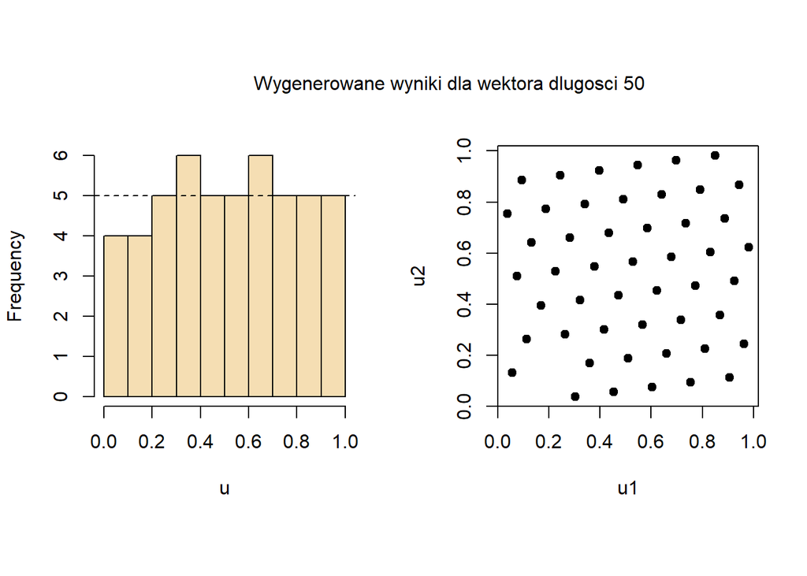

```r
u <- lcgen(50, 53, 20, 0, 1)
plotting(u)
```

Z łatwością możemy dostrzec wzorzec, sprawdźmy więc czy długość wygenerowanego wektora $n$ zmieni sytuację.

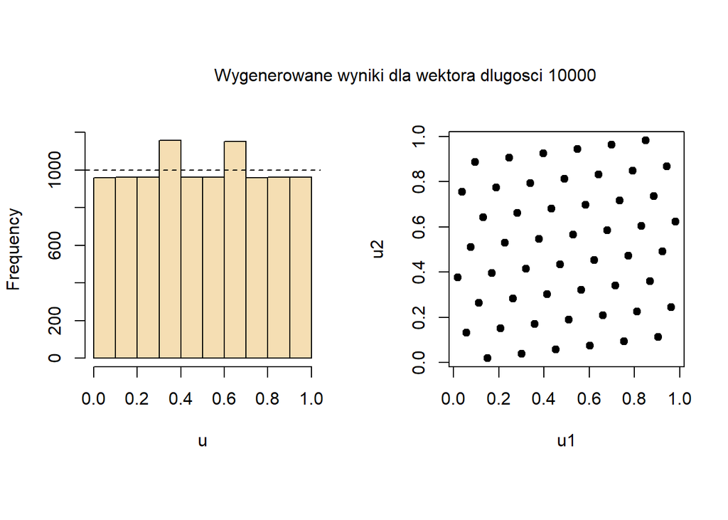

```r
u <- lcgen(10000, 53, 20, 0, 1)
plotting(u)
```

Niektóre wartości “wyrównały” do rozkładu jednostajnego, jednak inne się “przebiły”. Dodatkowo, wzorzec się pogłębia. Dobrane parametry ewidentnie dają dość słabe wyniki pod kątem losowości. Zmieńmy ich dobór i sprawdźmy więc drugi z wymienionych wyżej przykładów parametrów.

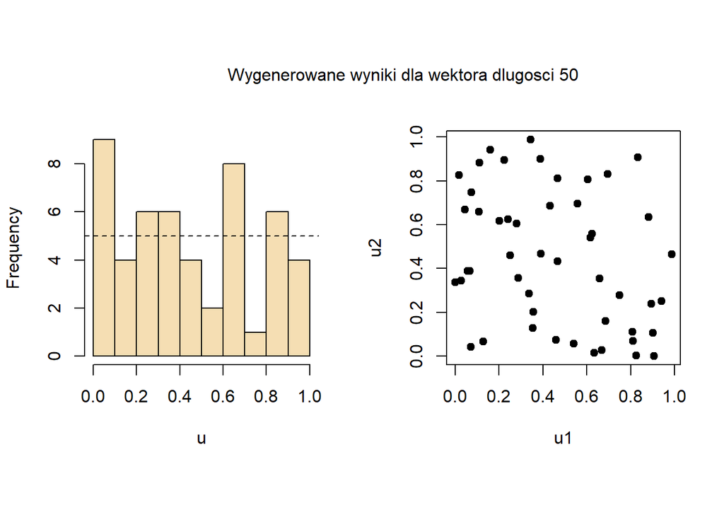

```r
u <- lcgen(50, 86436, 1093, 18257, 1)
plotting(u)
```

Przy $50$ wygenerowanych wartościach rozkład dosyć słabo przybliża rozkład jednostajny, jednak widać pewną losowość przy mapowaniu wartości. Zwiększmy liczbę próbek do $n=1000$.

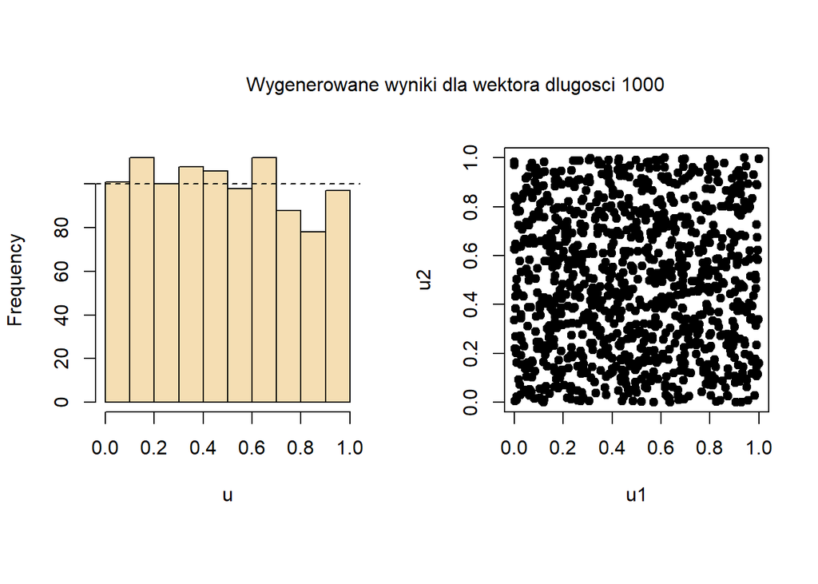

```r
u <- lcgen(1000, 86436, 1093, 18257, 1)
plotting(u)
```

Od razu widać znaczną poprawę, rozkład coraz bardziej przypomina rozkład jednostajny, a mapowanie zaczyna wypełniać kwadrat jednostkowy bez wyraźnego wzorca. Pójdźmy krok w przód i ponownie zwiększmy liczbę próbek, tym razem do $n=10000$.

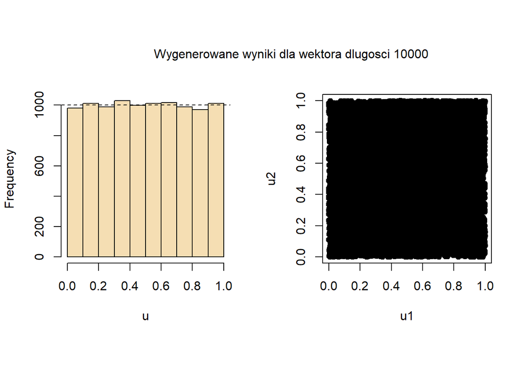

```r
u <- lcgen(10000, 86436, 1093, 18257, 1)
plotting(u)
```

Przykład idealnie ukazuje, jak wygenerowane wartości bardzo mocno zbliżyły się do rozkładu jednostajnego oraz wypełniły prawie cały kwadrat. W przeciwieństwie do pierwszych wizualizacji, tutaj możemy mówić o dobrze dobranych parametrach, które ukazują trafną pseudolosowość generatora. Weźmy jednak jeszcze nieco mniejszą próbkę $n=100$, aby zobaczyć pewne zależności względem parametrów.

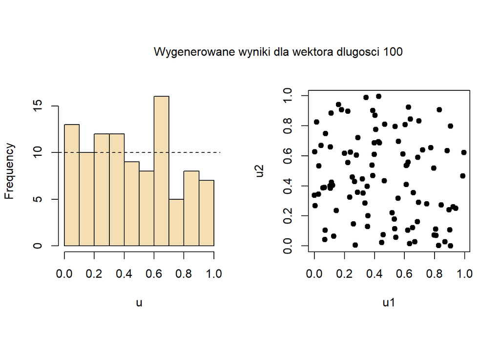

```r
u <- lcgen(100, 86436, 1093, 18257, 1)
plotting(u)
```

Teraz zmienimy ziarno losowe $x_0$ na wartość $x_0 = 142$.

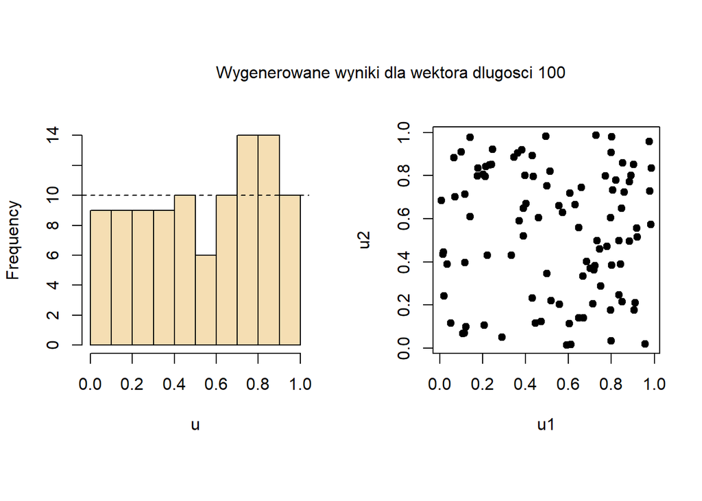

```r
u <- lcgen(100, 86436, 1093, 18257, 142)
plotting(u)
```

Możemy zauważyć na mapowaniu wygenerowanych punktów, że są one inaczej rozłożone. Jest to naturalna konsekwencja, bowiem ziarno inicjuje nam punkt początkowy i gwarantuje reprodukowalność wyników. W ostatnim etapie porównajmy powyższe wygenerowane wyniki z wynikami uzyskanymi poprzez generator liniowej kongruencji dostępny w bibliotece. W tym celu skorzystamy z biblioteki *fBasics* oraz funkcji *runif.lcg*. Rozpoczniemy od wygenerowania wartości dla próbki $n=100$.

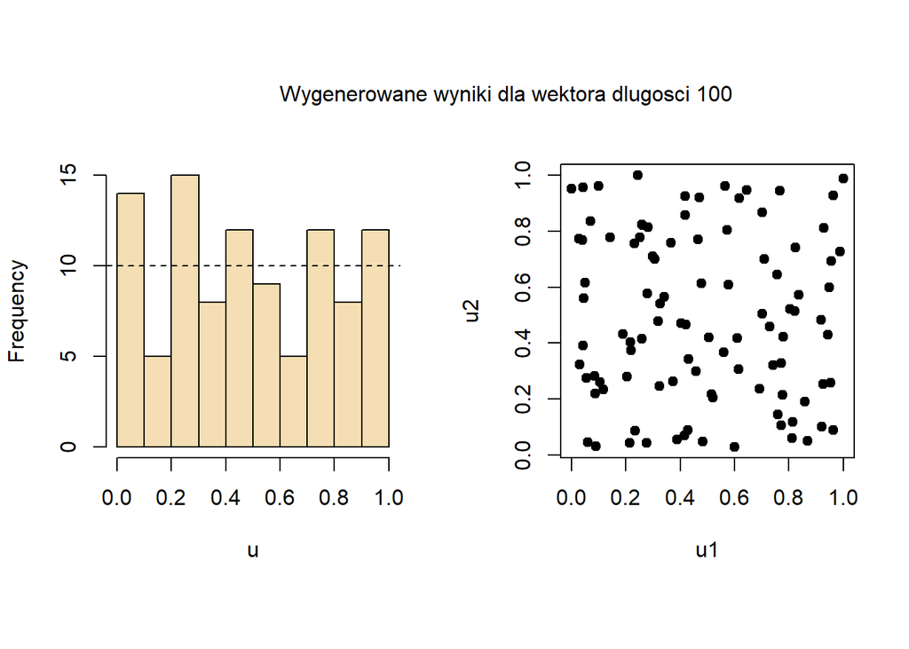

```r
library(fBasics)
set.lcgseed(142)
u <- runif.lcg(n=100, min=0, max=1)
plotting(u)
```

Rezultaty podobne, rozkład przypominający rozkład jednostajny, a mapowanie bez narzucających się wzorców. Sprawdźmy zatem, który szybciej uzyska wizualną zbieżność do rozkładu jednostajnego oraz wypełnienia kwadratu jednostkowego.

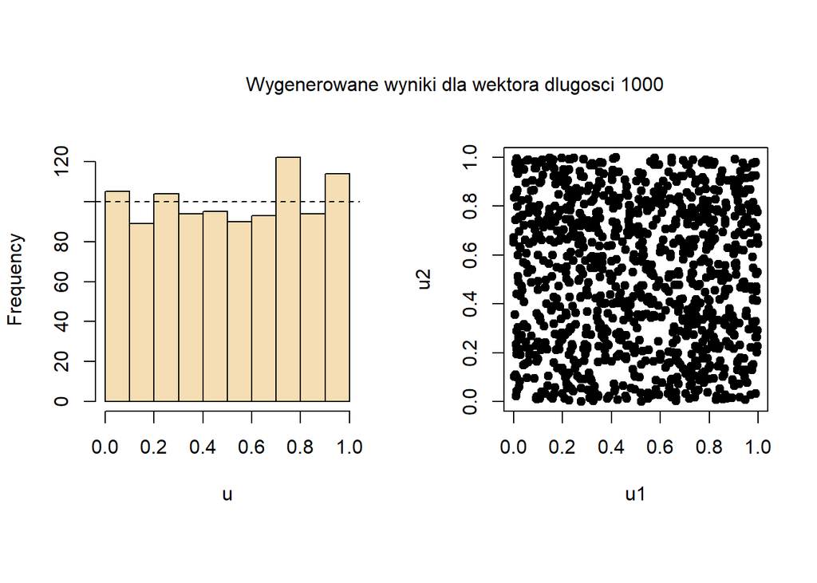

```r
u <- runif.lcg(n=1000, min=0, max=1)
plotting(u)
```

W dalszym ciągu rezultaty są porównywalne, weźmy więc $n=10000$.

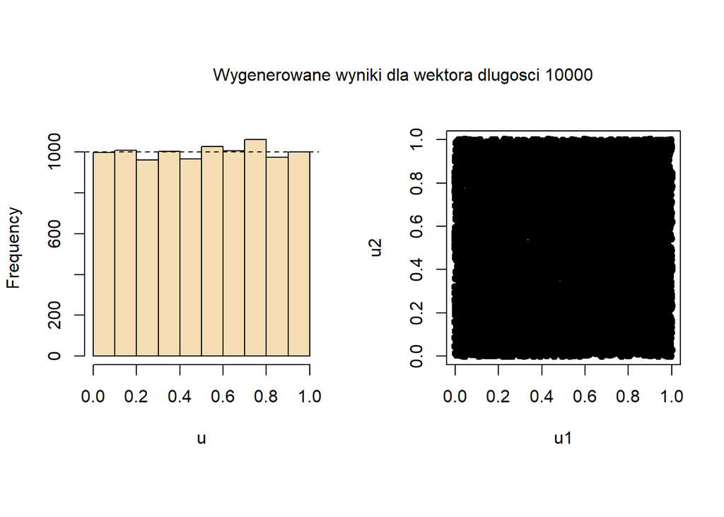

```r
u <- runif.lcg(n=10000, min=0, max=1)
plotting(u)
```

I w tym przypadku bez zmian, generator z biblioteki przy takiej wielkości próbki również prawie całościowo wypełnia powierzchnię kwadratu i jego rozkład jest mocno zbliżony do rozkładu jednostajnego. Jest to oczywiście spodziewany wniosek, bowiem obydwa podejścia stosują generator liniowej kongruencji. Ewentualne różnice mogą wynikać chociażby z czasu generowania liczb pseudolosowych ze względu chociażby na zastosowaną arytmetykę o czym wspomniano wcześniej. Dodatkowo, algorytm liniowej kongruencji może zostać zaadoptowany na kilka sposobów w zależności od przyjętych założeń, gdzie niektóre mogą być szybsze. W przypadku zaimplementowanego już generatora w bibliotece nie mamy jednak potrzeby inicjacji parametrów, które jak mogliśmy się przekonać, potrafią spowodować, iż wygenerowane liczby będą błędne i nie będą pochodziły z rozkładu jednostajnego.

## 1.7 Podsumowanie

W pierwszej części zaprezentowana została ogólna idea generatora liczb pseudolosowych wraz z warunkami na uzyskanie generatora efektywnego. Następnie podano przykładowy generator, jakim był generator kongruencji liniowej, wraz z algorytmem na jego uzyskanie. Później omówiono ogólne zasady konstrukcji generatora liczb pseudolosowych z istotnymi pojęciami jak długość okresu, reprodukowalność, prędkość, przenośność oraz losowość. Kolejnym etapem było omówienie generatora kongruencji liniowej. Podano jego ogólną postać oraz założenia, które musi spełniać żeby pozyskać z niego wiarygodne wyniki wygenerowanych liczb pseudolosowych. Na tej podstawie stworzono funkcję generatora oraz funkcje sprawdzające założenia, które złożono w jedną. Przystąpiono do sprawdzenia napisanego generatora na przykładach, tych które założenia spełniały, jak też tych które tego nie robiły. Uzyskane wyniki krótko zinterpretowano i ostatecznie wyciągnięto konkluzje o istotności założeń podczas konstrukcji. Omówiono także pokrótce problem przekroczenia zakresu liczb całkowitych. Ostatnim etapem była wizualizacja wyników oraz ich ocena. Przytoczono dwa wcześniej użyte przykłady z czego wysunięto odpowiednie wnioski. Poprawne rezultaty zestawiono także z wynikami uzyskanymi przy pomocy generatora wbudowanego w jednej z bibliotek i je opisano. Sposobów na stworzenie poprawnego generatora jest wiele, jednak zawsze trzeba sprawdzić założenia, a przede wszystkim je spełniać.

# 2 Implementacja generatora liczb pseudolosowych z zadanych rozkładów

## 2.1 Wprowadzenie

Mając stworzony generator liczb pseudolosowych zakładamy dostępność idealnej sekwencji liczb losowych, czyli bierzemy pod uwagę ciąg niezależnych zmiennych losowych $U_1, U_2, ...$, gdzie każda z nich spełnia
$$P(U_i\leq u) = \begin{cases}
0, & u <0 \\
u, & 0 \leq u <1 \\
1, & u >1
\end{cases}$$
więc pochodzi z rozkładu jednostajnego $U([0,1])$. Często chcemy uzyskać ciąg liczb wygenerowanych z innego rozkładu niż rozkład jednostajny, w tym celu przeważnie wykorzystuje się transformacje na próbkach z rozkładu jednostajnego w celu przekształcenia ich w taki sposób, aby pochodziły z innego, żądanego rozkładu. Jedną z takich metod jest odwrotna transformacja.

Podczas implementacji algorytmów do generowania liczb z różnych rozkładu będziemy korzystać z generatora liczb pseudolosowych z rozkładu jednostajnego utworzonego wcześniej, jak też z funkcji kontrolującej założenia. Przy czym za wartości $m$, $a$, $c$, $x$ będziemy brali
$$m = 2^{31} -1, \quad a = 16807, \quad c=24, \quad x=1$$
jako wartości prawidłowe generatora, wartości
$$m = 2^{11} +1, \quad a = 64, \quad c=73, \quad x=1$$
jako wartości względnie poprawne oraz
$$m = 8, \quad a=2, \quad c=1,\quad x=1$$
jako wartości nieprawidłowe.

## 2.2 Metoda odwrotnej transformacji

Przypuśćmy, że chcemy próbkować z dystrybuanty, a więc chcemy wygenerować zmienną losową $X$ z własnością taką, że $P(X \leq x) = F(x)$ dla każdego $x$. Wówczas metoda odwrotnej transformacji wygląda następująco
$$X = F^{-1}(U), \quad U \sim U([0,1]),$$
gdzie $F^{-1}$ jest odwrotną do dystrybuanty $F$ i jest poprawnie określona gdy $F$ jest ściśle rosnąca. W celu obejścia problemu, w którym $F$ jest spłaszczona (gdyż tam funkcja odwrotna nie będzie poprawnie zdefiniowana), funkcję odwrotną definiuje się poprzez
$$F^{-1}(u) = \inf{\{x: \quad F(x)\geq u\}}.$$
Zauważmy jednak, że jeśli $F$ jest stała na pewnym przedziale $[a,b]$, a $X$ ma dystrybuantę $F$ to
$$P(a < X \leq b) = F(b) - F(a) = 0$$
więc takie obszary mają zerowe prawdopodobieństwo dla wystąpienia tam zmiennej losowej. Jeśli $F$ ma ciągłą pochodną (gęstość) to wówczas jest ściśle rosnąca wszędzie, gdzie gęstość nie jest zerowa. W celu pokazania, że metoda odwrotnej transformacji generuje próbki z dystrybuanty $F$, sprawdzamy rozkład $X$, który zwraca
$$P(X\leq x) = P(F^{-1}(U) \leq x) = P(U\leq F(x)) = F(x)$$
Co więcej, można interpretować tą metodę jako fakt, że percentyl, w który $X$ “wpada” ma rozkład jednostajny. Metoda odwrotnej transformacji wybiera jednostajnie percentyl, który następnie mapuje do odpowiadającej wartości zmiennej losowej.

## 2.3 Rozkład wykładniczy

```r
exp_rand <- function(N,theta,m=valid[1], a=valid[2], c=valid[3], x=valid[4], mode="self"){
  if (check_assumptions(m,a,c) == 'Założenia spełnione!' & mode=="self"){
    U <- lcgen(N,m,a,c,x)
    X <- -1/theta*log(U)

  }
  else if (check_assumptions(m,a,c) != 'Założenia spełnione!' & mode=="self"){
    print("Wartości dla założeń nieprawidłowe!")
    U <- lcgen(N,m,a,c,x)
    X <- -1/theta*log(U)

  }
  else {
    U <- runif(N)
    X <- -1/theta*log(U)
  }
  return(X)
}
```

Stworzymy też funkcję generującą histogram wraz z funkcją gęstości oraz zwracającą podstawowe statystyki opisowe, czyli średnią, medianę, wariancję i odchylenie standardowe oraz wartości teoretyczne.

```r
plot_and_check <- function(X, theta, title){
  hist(X, prob=TRUE, col="grey", main=title)
  lines(density(X), col="blue", lwd=2)

  mean = 1/theta
  median = log(2)/theta
  var = 1/(theta^2)
  std = sqrt(var)

  mean_x = mean(X)
  median_x = median(X)
  var_x = var(X)
  std_x = sqrt(var_x)

  t <- c(mean, median, var, std)
  p <- c(mean_x, median_x, var_x, std_x)

  print("Wartości teoretyczne:")
  print(paste("Średnia: ", mean, ", Mediana: ", median))
  print(paste("Wariancja: ", var, ", STD: ", std))
  print("Wartości wygenerowane:")
  print(paste("Średnia: ", mean_x, ", Mediana: ", median_x))
  print(paste("Wariancja: ", var_x, ", STD: ", std_x))
  }
```

Sprawdźmy dla wartości nieprawidłowych

```r
exp <- exp_rand(N=1000, theta=1, m=nonvalid[1], a=nonvalid[2], c=nonvalid[3], x=nonvalid[4])
```

```
## [1] "Wartości dla założeń nieprawidłowe!"
```

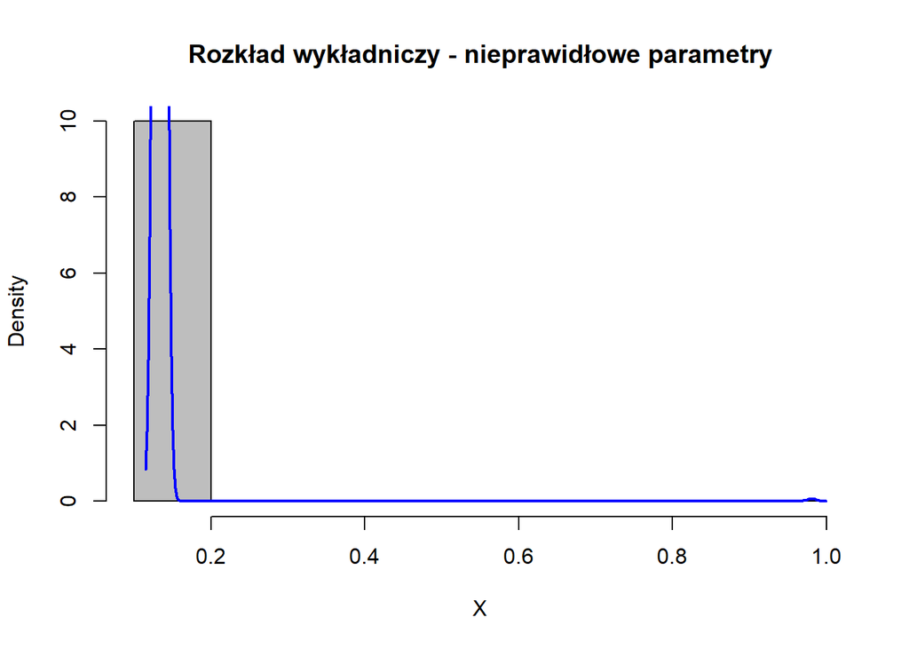

```
## [1] "Wartości teoretyczne:"
## [1] "Średnia:  1 , Mediana:  0.693147180559945"
## [1] "Wariancja:  1 , STD:  1"
## [1] "Wartości wygenerowane:"
## [1] "Średnia:  0.13437869048491 , Mediana:  0.133531392624523"
## [1] "Wariancja:  0.000717913664216733 , STD:  0.0267939109541092"
```

```r
plot_and_check(exp, theta=1, "Rozkład wykładniczy - nieprawidłowe parametry")
```

Można bez problemu zauważyć absurdalne rezultaty przy braku spełnionych założeń dla generatora liczb z rozkładu jednostajnego. Co więcej, statystyki opisowe są znacząco różne od tych teoretycznych. Sprawdźmy generator dla wartości względnie poprawnych.

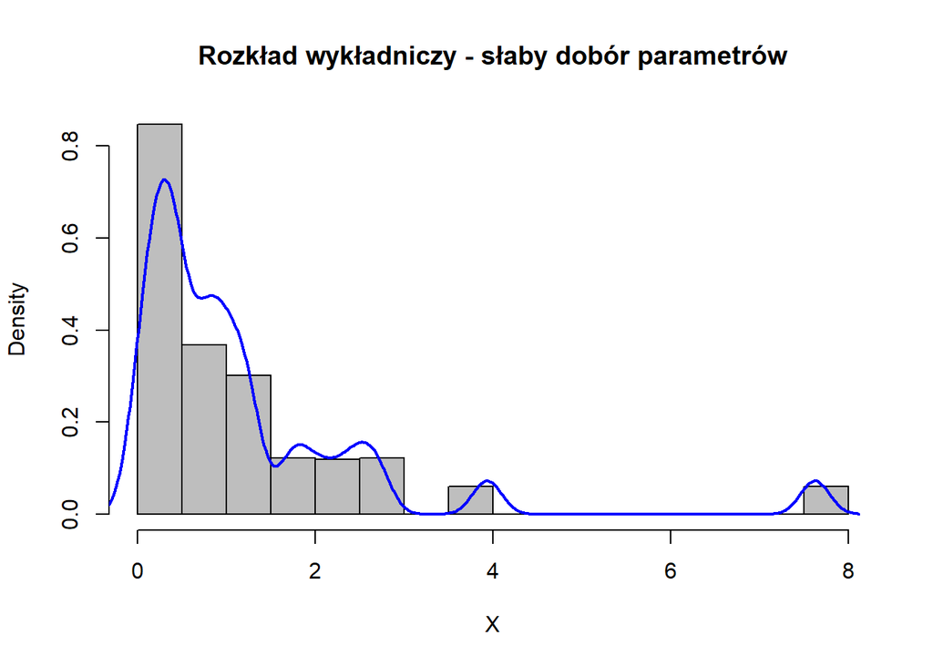

```
## [1] "Wartości teoretyczne:"
## [1] "Średnia:  1 , Mediana:  0.693147180559945"
## [1] "Wariancja:  1 , STD:  1"
## [1] "Wartości wygenerowane:"
## [1] "Średnia:  1.185472049113 , Mediana:  0.781357199232675"
## [1] "Wariancja:  2.08071716697754 , STD:  1.44246912167212"
```

```r
exp <- exp_rand(N=1000, theta=1, m=badvalid[1], a=badvalid[2], c=badvalid[3], x=badvalid[4])
plot_and_check(exp, theta=1, title= "Rozkład wykładniczy - słaby dobór parametrów")
```

Widać poprawę wyników, ale występują niepożądane “pagórki”. Co więcej, statystyki opisowe, choć bardziej zbliżone, to wciąż dość mocno odstają od wartości teoretycznych. Sprawdźmy dla wartości prawidłowych.

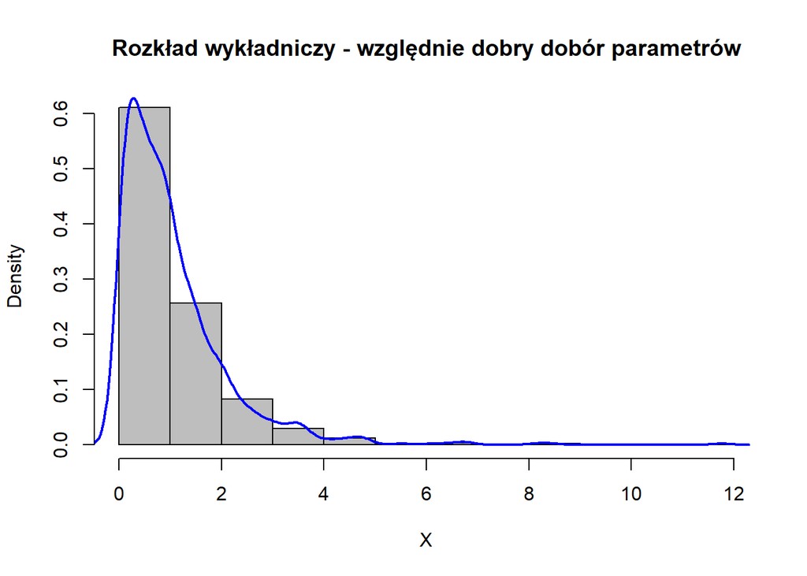

```
## [1] "Wartości teoretyczne:"
## [1] "Średnia:  1 , Mediana:  0.693147180559945"
## [1] "Wariancja:  1 , STD:  1"
## [1] "Wartości wygenerowane:"
## [1] "Średnia:  1.04619757800968 , Mediana:  0.788099951887279"
## [1] "Wariancja:  1.16269013278082 , STD:  1.07828110100327"
```

```r
exp <- exp_rand(N=1000, theta=1, m=valid[1], a=valid[2], c=valid[3], x=valid[4])
plot_and_check(exp, theta=1, title = "Rozkład wykładniczy - względnie dobry dobór parametrów")
```

Widzimy teraz, że “pagórki” zostały prawie całkowicie wyeliminowane i nasz rozkład przypomina rozkład wykładniczy. Dodatkowo, statystyki wygenerowane są mocno zbliżone do statystyk teoretycznych. Ewentualne mocniejsze odchylenia są widoczne przy wariancji. Przyrównajmy go z rozkładem wygenerowanym za pomocą generatora wbudowanego.

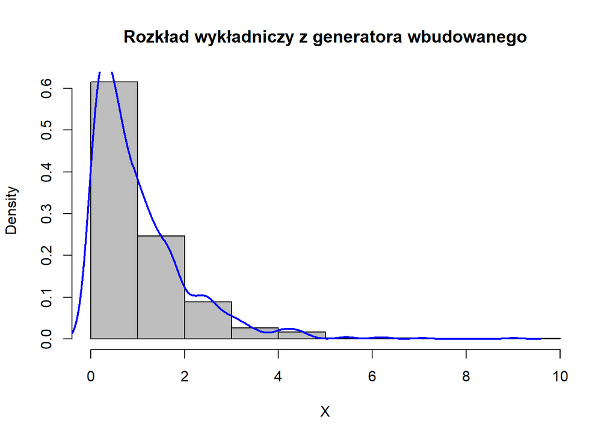

```
## [1] "Wartości teoretyczne:"
## [1] "Średnia:  1 , Mediana:  0.693147180559945"
## [1] "Wariancja:  1 , STD:  1"
## [1] "Wartości wygenerowane:"
## [1] "Średnia:  1.02684560066783 , Mediana:  0.709554898510587"
## [1] "Wariancja:  1.02905049911324 , STD:  1.01442126314132"
```

```r
exp <- rexp(1000, rate=1)
plot_and_check(exp, theta=1, title="Rozkład wykładniczy z generatora wbudowanego")
```

Możemy zauważyć, że wbudowany generator radzi sobie podobnie. Również statystyki wygenerowane w niewielki sposób są odchylone od teoretycznych. Jednak należy zauważyć, że odpowiednio dobrane parametry dla generatora liniowej kongruencji są kluczowe. W przypadku dobrania takich niespełniających założeń lub o zbyt małej “losowości” nasze wyniki nie będą satysfakcjonujące, więc powinniśmy zwracać uwagę na dobranie takich parametrów dla których uzyskana losowość będzie wystarczająca do wygenerowania próbki pseudolosowej pochodzącej z innej rodziny rozkładów. Sprawdźmy wyniki dla innych parametrów $\theta$, w tym dla $\theta = 3/2$.

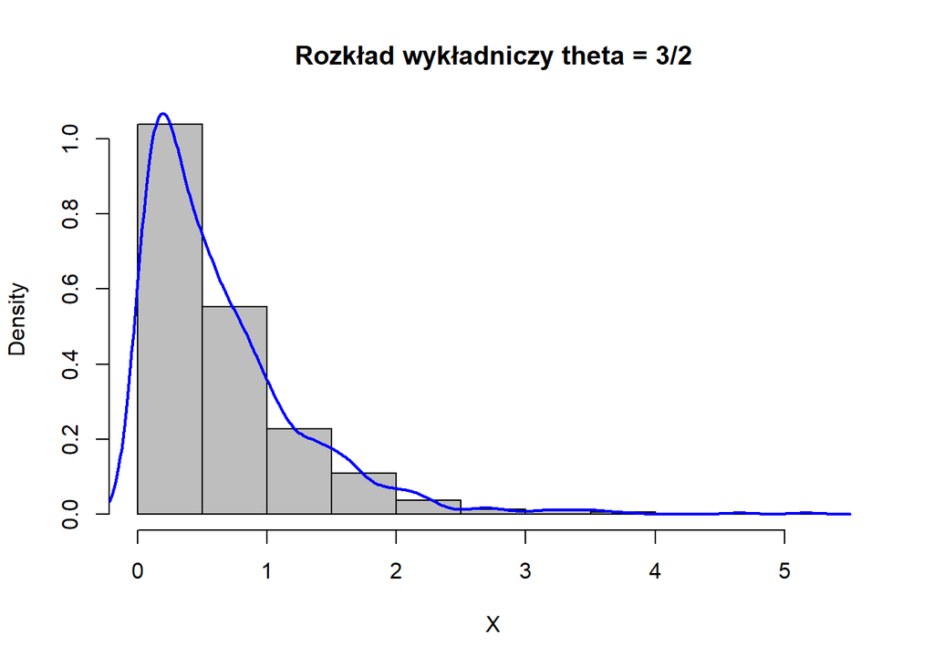

```
## [1] "Wartości teoretyczne:"
## [1] "Średnia:  0.666666666666667 , Mediana:  0.462098120373297"
## [1] "Wariancja:  0.444444444444444 , STD:  0.666666666666667"
## [1] "Wartości wygenerowane:"
## [1] "Średnia:  0.645969438282154 , Mediana:  0.476900217426985"
## [1] "Wariancja:  0.387849165506708 , STD:  0.622775373233968"
```

```r
exp6 <- exp_rand(N=1000, theta=3/2, mode="implemented")
plot_and_check(exp6, theta=3/2, title = "Rozkład wykładniczy theta = 3/2")
```

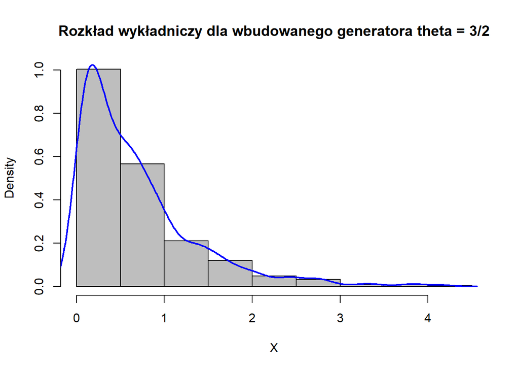

```
## [1] "Wartości teoretyczne:"
## [1] "Średnia:  0.666666666666667 , Mediana:  0.462098120373297"
## [1] "Wariancja:  0.444444444444444 , STD:  0.666666666666667"
## [1] "Wartości wygenerowane:"
## [1] "Średnia:  0.681644497188962 , Mediana:  0.489477576594109"
## [1] "Wariancja:  0.449970129727024 , STD:  0.670798128893503"
```

```r
exp7 <- rexp(1000, rate=3/2)
plot_and_check(exp7, theta=3/2, title= "Rozkład wykładniczy dla wbudowanego generatora theta = 3/2")
```

## 2.4 Rozkład Weibulla

Rozkład Weibulla o parametrach $\theta$ oraz $k$ ma dystrybuantę
$$F(x) = 1-e^{-(x/\theta)^k}, \quad x\geq 0.$$
W zależności od doboru $k$ możemy tak naprawdę otrzymać rozkład wykładniczy ($k=1$), czy też Rayleigha ($k=2$) a nawet rozkład normalny (dla dużych $k$). Poprzez odwrócenie dystrybuanty uzyskamy możliwość stworzenia algorytmu do generowania próbek z rozkładu Weibulla poprzez rozkład jednostajny
$$X = |\theta|(-\log{(1-U)})^{1/k},$$
ale ponieważ $1-U$ ma taki sam rozkład jak $U$ możemy zapisać jako
$$X = |\theta|(-\log{(U)})^{1/k}.$$
Generator stworzymy wykorzystując wcześniej stworzony generator liczb pseudolosowych z rozkładu jednostajnego.

```r
weibull_rand <- function(N,theta,k,m=valid[1], a=valid[2], c=valid[3], x=valid[4], mode="self"){
  if (check_assumptions(m,a,c) == 'Założenia spełnione!' & mode=="self"){
    U <- lcgen(N,m,a,c,x)
    X <- abs(theta)*(-log(U))^(1/k)

  }
  else if (check_assumptions(m,a,c) != 'Założenia spełnione!' & mode=="self"){
    print("Wartości dla założeń nieprawidłowe!")
    U <- lcgen(N,m,a,c,x)
    X <- abs(theta)*(-log(U))^(1/k)

  }
  else {
    U <- runif(N)
    X <- abs(theta)*(-log(U))^(1/k)

  }
  return(X)
}
```

Stworzymy też funkcję generującą histogram wraz z funkcją gęstości oraz zwracającą podstawowe statystyki opisowe, czyli średnią, medianę, wariancję i odchylenie standardowe oraz wartości teoretyczne.

```r
plot_and_check_weibull <- function(X, theta, k, title){
  hist(X, prob=TRUE, col="grey", main=title)
  lines(density(X), col="blue", lwd=2)

  mean = theta*gamma(1+1/k)
  median = theta*log(2)^(1/k)
  var = theta^2 * gamma(1+2/k) - (theta*gamma(1+1/k))^2
  std = sqrt(var)

  mean_x = mean(X)
  median_x = median(X)
  var_x = var(X)
  std_x = sqrt(var_x)

  t <- c(mean, median, var, std)
  p <- c(mean_x, median_x, var_x, std_x)

  print("Wartości teoretyczne:")
  print(paste("Średnia: ", mean, ", Mediana: ", median))
  print(paste("Wariancja: ", var, ", STD: ", std))
  print("Wartości wygenerowane:")
  print(paste("Średnia: ", mean_x, ", Mediana: ", median_x))
  print(paste("Wariancja: ", var_x, ", STD: ", std_x))

  }
```

Sprawdźmy dla wartości nieprawidłowych

```r
weib <- weibull_rand(N=1000, theta=1, k=1, m=nonvalid[1], a=nonvalid[2], c=nonvalid[3], x=nonvalid[4])
```

```
## [1] "Wartości dla założeń nieprawidłowe!"
```

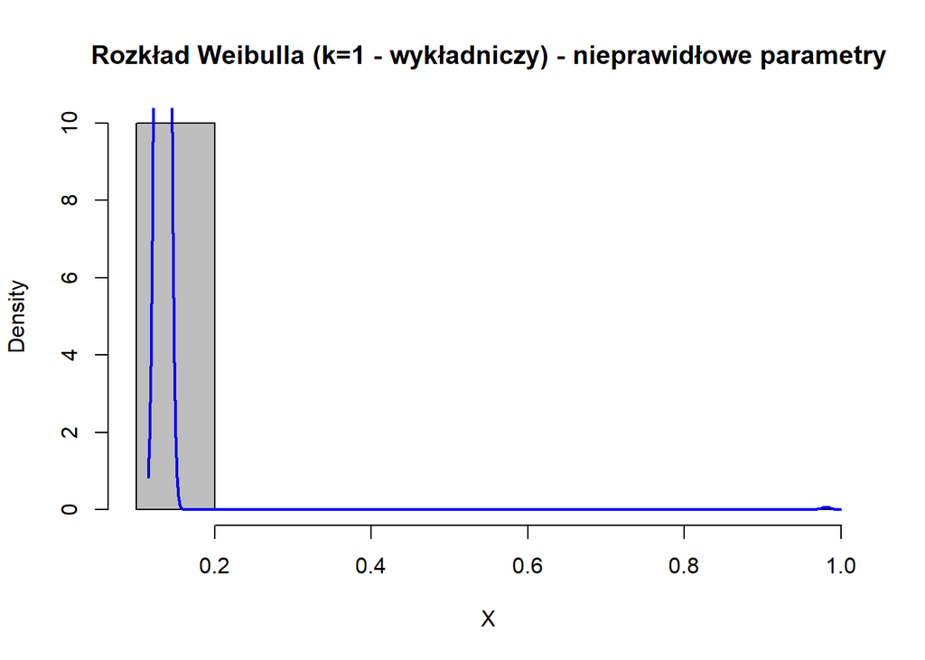

```
## [1] "Wartości teoretyczne:"
## [1] "Średnia:  1 , Mediana:  0.693147180559945"
## [1] "Wariancja:  1 , STD:  1"
## [1] "Wartości wygenerowane:"
## [1] "Średnia:  0.13437869048491 , Mediana:  0.133531392624523"
## [1] "Wariancja:  0.000717913664216733 , STD:  0.0267939109541092"
```

```r
plot_and_check_weibull(weib, theta=1, k =1, title = "Rozkład Weibulla (k=1 - wykładniczy) - nieprawidłowe parametry")
```

Widać bez problemu identyczne rezultaty, jak w przypadku generatora rozkładu Wykładniczego. Otrzymane rezultaty również są nieprawidłowe, a statystyki znacząco się różnią. Sprawdźmy generator dla wartości względnie poprawnych.

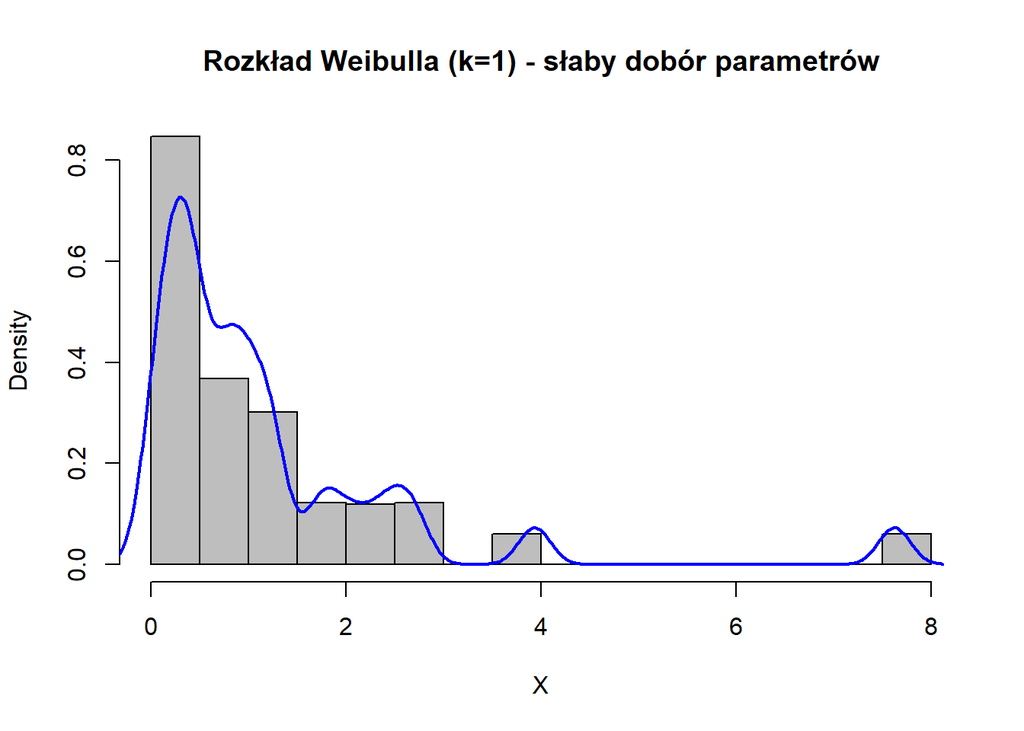

```
## [1] "Wartości teoretyczne:"
## [1] "Średnia:  1 , Mediana:  0.693147180559945"
## [1] "Wariancja:  1 , STD:  1"
## [1] "Wartości wygenerowane:"
## [1] "Średnia:  1.185472049113 , Mediana:  0.781357199232675"
## [1] "Wariancja:  2.08071716697754 , STD:  1.44246912167212"
```

```r
weib <- weibull_rand(N=1000, theta=1, k =1, m=badvalid[1], a=badvalid[2], c=badvalid[3], x=badvalid[4])
plot_and_check_weibull(weib, theta=1, k=1, title= "Rozkład Weibulla (k=1) - słaby dobór parametrów")
```

Ponownie widać poprawę wyników, ale tutaj także z “pagórkami”. Sprawdźmy dla wartości prawidłowych.

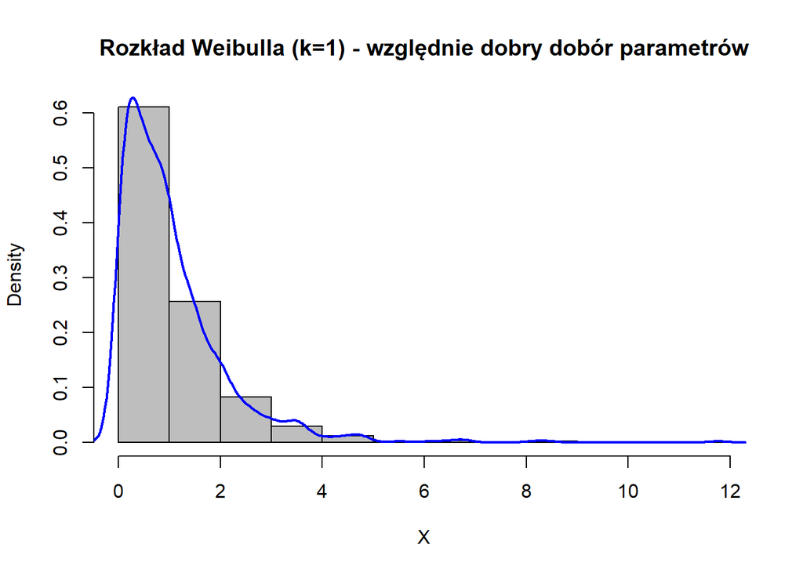

```
## [1] "Wartości teoretyczne:"
## [1] "Średnia:  1 , Mediana:  0.693147180559945"
## [1] "Wariancja:  1 , STD:  1"
## [1] "Wartości wygenerowane:"
## [1] "Średnia:  1.04619757800968 , Mediana:  0.788099951887279"
## [1] "Wariancja:  1.16269013278082 , STD:  1.07828110100327"
```

```r
weib <- weibull_rand(N=1000, theta=1, k=1, m=valid[1], a=valid[2], c=valid[3], x=valid[4])
plot_and_check_weibull(weib, theta=1, k=1, title = "Rozkład Weibulla (k=1) - względnie dobry dobór parametrów")
```

Widzimy teraz, że “pagórki” zostały prawie całkowicie wyeliminowane i nasz rozkład przypomina rozkład wykładniczy (tak powinno wychodzić przy $k=1$). Dodatkowo, statystyki wygenerowane są mocno zbliżone do statystyk teoretycznych. Pokazaliśmy już, zarówno w poprzednim raporcie, jak też w tym na dwóch przykładach, że odpowiedni dobór parametrów dla generatora liniowej kongruencji jest niezbędny, aby uzyskać satysfakcjonujące rezultaty - w końcu to na nich opieramy nasze kolejne generatory. W celu zredukowania ilości tekstu, pomijać w dalszej części będziemy testowanie na błędnych parametrach z racji, iż pokazane już została ich istotność. Co więcej, jak zostało wspomniane w poprzednim raporcie, w przypadku użycia generatora liczb pseudolosowych z rozkładu jednostajnego nie ma potrzeby doboru odpowiednich parametrów. Uwzględniając to, jak również fakt, że do naszego generatora z rozkładu jednostajnego moglibyśmy dobrać zapewne jeszcze lepsze wartości parametrów, dalej korzystać będziemy z generatora wbudowanego dla liczb z rozkładu jednostajnego. Takie podejście zapewni najrzetelniejsze odzwierciedlenie pseudolosowości. Specjalnie na taki przypadek został w każdej funkcji zaimplementowany parametr “mode” zezwalający na wybór generatora. Sprawdźmy teraz wartości dla innych parametrów $k$ oraz $\theta$ i przyrównajmy go z rozkładem wygenerowanym za pomocą generatora wbudowanego.

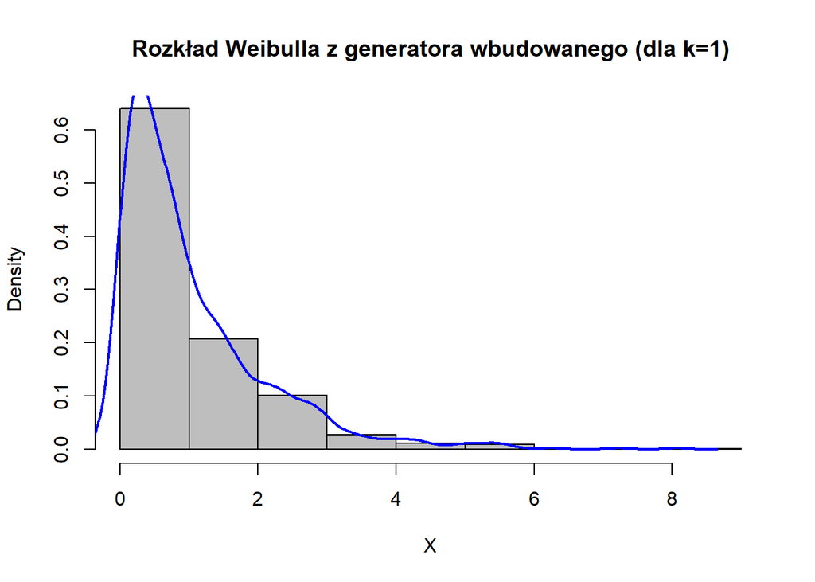

```
## [1] "Wartości teoretyczne:"
## [1] "Średnia:  1 , Mediana:  0.693147180559945"
## [1] "Wariancja:  1 , STD:  1"
## [1] "Wartości wygenerowane:"
## [1] "Średnia:  1.03458122784783 , Mediana:  0.692456660967373"
## [1] "Wariancja:  1.14516093058238 , STD:  1.07012192323229"
```

```r
exp <- rweibull(1000, scale=1, shape=1)
plot_and_check_weibull(exp, theta=1, k=1,title="Rozkład Weibulla z generatora wbudowanego (dla k=1)")
```

Możemy zauważyć, że wbudowany generator radzi sobie podobnie. Również statystyki wygenerowane w niewielki sposób są odchylone od teoretycznych. Zupełnie jak w przypadku rozkładu wykładniczego, jest to ważna informacja, gdyż mówi nam o poprawnym sposobie budowania generatora rozkładu Weibulla - przy takim doborze parametru $k$ dokładnie rozkład wykładniczy jest pożądany. Sprawdźmy wyniki dla innych parametrów $\theta$ i $k$, w tym dla $\theta = 2$ oraz $k=2$ (rozkład Rayleigha).

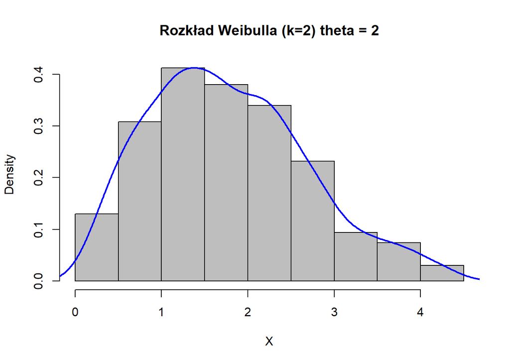

```
## [1] "Wartości teoretyczne:"
## [1] "Średnia:  1.77245385090552 , Mediana:  1.6651092223154"
## [1] "Wariancja:  0.858407346410206 , STD:  0.926502750352208"
## [1] "Wartości wygenerowane:"
## [1] "Średnia:  1.77630551175518 , Mediana:  1.6852920030274"
## [1] "Wariancja:  0.83505510236383 , STD:  0.913813494299482"
```

```r
weib <- weibull_rand(N=1000, theta=2, k=2, mode="implemented")
plot_and_check_weibull(weib, theta=2, k=2, title = "Rozkład Weibulla (k=2) theta = 2")
```

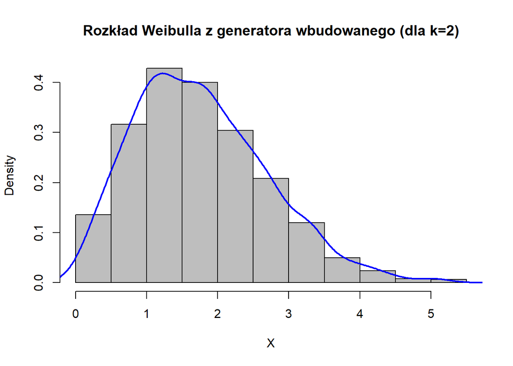

```
## [1] "Wartości teoretyczne:"
## [1] "Średnia:  1.77245385090552 , Mediana:  1.6651092223154"
## [1] "Wariancja:  0.858407346410206 , STD:  0.926502750352208"
## [1] "Wartości wygenerowane:"
## [1] "Średnia:  1.76308749075115 , Mediana:  1.67490295365386"
## [1] "Wariancja:  0.870477289574239 , STD:  0.932993724295206"
```

```r
w2 <- rweibull(1000, scale=2, shape=2)
plot_and_check_weibull(w2, theta=2, k=2,title="Rozkład Weibulla z generatora wbudowanego (dla k=2)")
```

Otrzymaliśmy ponownie bardzo zbliżone wyniki. Wizualizacja rozkładów (za pomocą generatora wbudowanego oraz własnego) pokazuje jak zbliżone są do siebie. Jednak to statystyki są tutaj kluczowe i najrzetelniejsze, a wartości są niewiele odstające od wartości teoretycznych. Można wywnioskować, że stworzony przez nas generator całkiem dobrze sobie radzi w porównaniu do generatora wbudowanego.

## 2.5 Rozkład arcusa sinusa

Rozkład arcusa sinusa modeluje czas, w którym ruch Browna osiąga swoje maksimum na przedziale $[0,1]$ i wyrazić go można dystrybuantą
$$F(x) = \frac{2}{\pi}\arcsin(\sqrt{x}), \quad x\in [0,1].$$
Poprzez odwrócenie dystrybuanty uzyskamy możliwość stworzenia algorytmu do generowania próbek z rozkładu arcusa sinusa poprzez rozkład jednostajny
$$X = \sin^2(U\pi/2),$$
ale ponieważ możemy skorzystać z własności $2\sin^2(t)=1-\cos(2t)$ to wówczas
$$X = \frac{1}{2} - \frac{1}{2}\cos(U\pi).$$
Generator stworzymy, ponownie, wykorzystując wcześniej stworzony generator liczb pseudolosowych z rozkładu jednostajnego.

```r
arcsin_rand <- function(N,m=valid[1], a=valid[2], c=valid[3], x=valid[4], mode="self"){
  if (check_assumptions(m,a,c) == 'Założenia spełnione!' & mode=="self"){
    U <- lcgen(N,m,a,c,x)
    X <- 1/2 - 1/2*cos(U*pi)
  }
  else if (check_assumptions(m,a,c) != 'Założenia spełnione!' & mode=="self"){
    print("Wartości dla założeń nieprawidłowe!")
    U <- lcgen(N,m,a,c,x)
    X <- 1/2 - 1/2*cos(U*pi)
  } else {
    U <- runif(N)
    X <- 1/2 - 1/2*cos(U*pi)

  }
  return(X)
}
```

Stworzymy też, jeszcze raz dla nowego rozkładu, funkcję generującą histogram wraz z funkcją gęstości oraz zwracającą podstawowe statystyki opisowe, czyli średnią, medianę, wariancję i odchylenie standardowe oraz wartości teoretyczne.

```r
plot_and_check_arcsin <- function(X, theta, k, title){
  hist(X, prob=TRUE, col="grey", main=title)
  lines(density(X), col="blue", lwd=2)

  mean = 1/2
  median = 1/2
  var = 1/8
  std = sqrt(var)

  mean_x = mean(X)
  median_x = median(X)
  var_x = var(X)
  std_x = sqrt(var_x)

  t <- c(mean, median, var, std)
  p <- c(mean_x, median_x, var_x, std_x)

  print("Wartości teoretyczne:")
  print(paste("Średnia: ", mean, ", Mediana: ", median))
  print(paste("Wariancja: ", var, ", STD: ", std))
  print("Wartości wygenerowane:")
  print(paste("Średnia: ", mean_x, ", Mediana: ", median_x))
  print(paste("Wariancja: ", var_x, ", STD: ", std_x))

  }
```

Wygenerujmy pewną próbkę i porównajmy wartości statystyk do wartości teoretycznych.

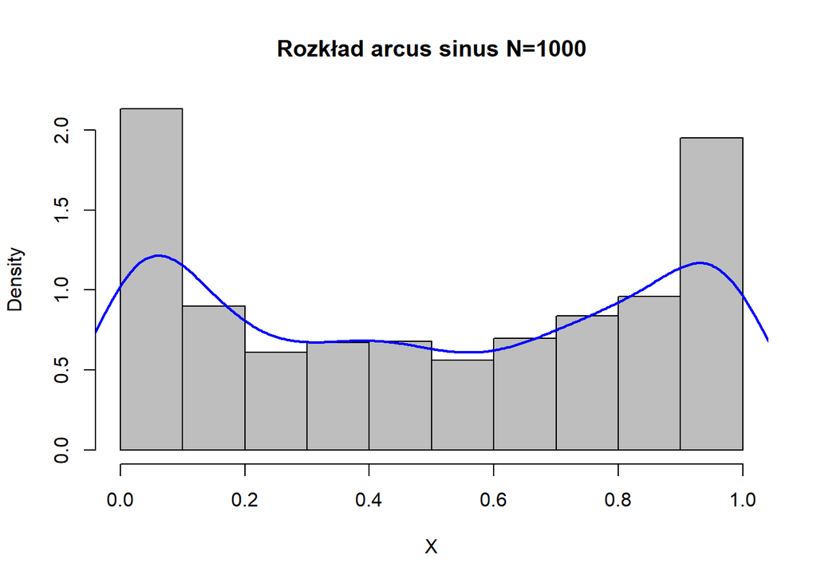

```
## [1] "Wartości teoretyczne:"
## [1] "Średnia:  0.5 , Mediana:  0.5"
## [1] "Wariancja:  0.125 , STD:  0.353553390593274"
## [1] "Wartości wygenerowane:"
## [1] "Średnia:  0.499071763254419 , Mediana:  0.501142834514879"
## [1] "Wariancja:  0.125971450146862 , STD:  0.354924569657923"
```

```r
arc <- arcsin_rand(N=1000, mode="implemented")
plot_and_check_arcsin(arc, title = "Rozkład arcus sinus N=1000")
```

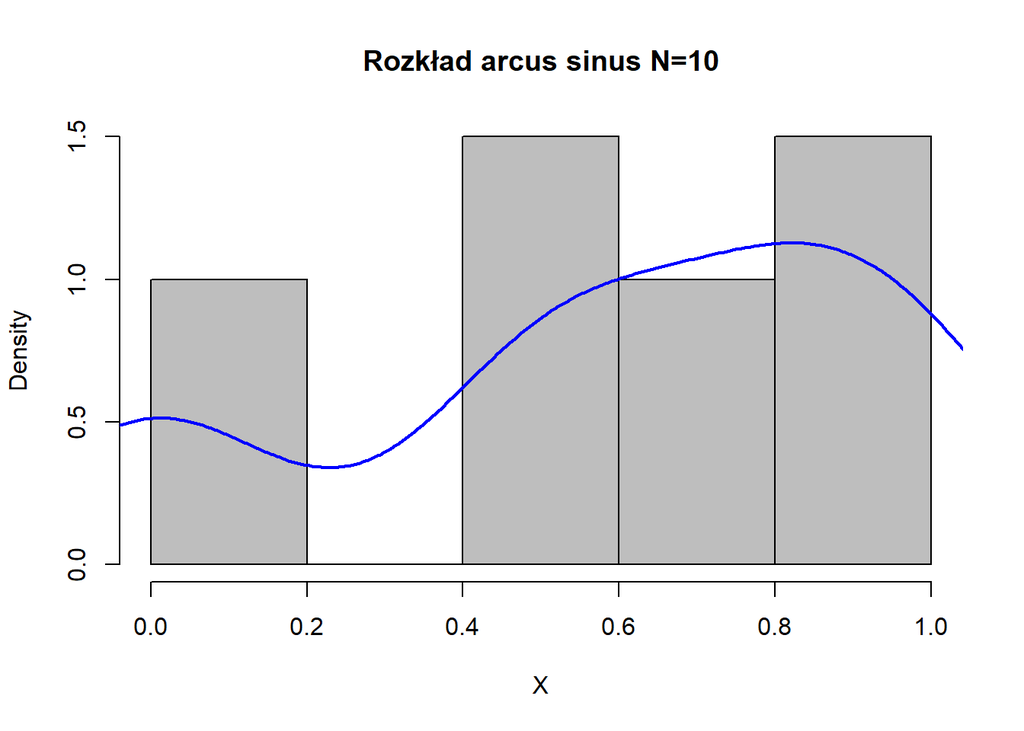

```
## [1] "Wartości teoretyczne:"
## [1] "Średnia:  0.5 , Mediana:  0.5"
## [1] "Wariancja:  0.125 , STD:  0.353553390593274"
## [1] "Wartości wygenerowane:"
## [1] "Średnia:  0.597999085786558 , Mediana:  0.669995655121375"
## [1] "Wariancja:  0.131197918839162 , STD:  0.362212532692013"
```

```r
arc <- arcsin_rand(N=10, mode="implemented")
plot_and_check_arcsin(arc, title = "Rozkład arcus sinus N=10")
```

Teraz widzimy już znaczne odchylenia, ale jest to spodziewana sytuacja. Sprawdźmy dla większej próbki $N=10000$.

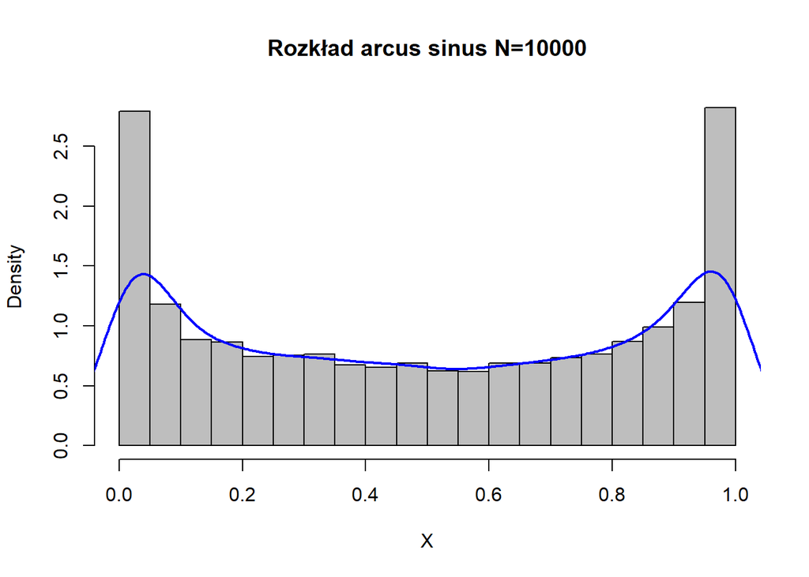

```
## [1] "Wartości teoretyczne:"
## [1] "Średnia:  0.5 , Mediana:  0.5"
## [1] "Wariancja:  0.125 , STD:  0.353553390593274"
## [1] "Wartości wygenerowane:"
## [1] "Średnia:  0.502074554166932 , Mediana:  0.498911969987616"
## [1] "Wariancja:  0.123008728954995 , STD:  0.350726002678722"
```

```r
arc <- arcsin_rand(N=10000, mode="implemented")
plot_and_check_arcsin(arc, title = "Rozkład arcus sinus N=10000")
```

Wartości są niemal tej samej wartości. Generator osiąga świetne wyniki, jednak nie udało mi się znaleźć wbudowanego generatora tego rozkładu, do którego można by było dodatkowo zestawić otrzymane rezultaty. Przejdźmy więc do kolejnego generatora liczb z rozkładu normalnego.

## 2.6 Rozkład normalny

```r
normal_double <- function(N,m=valid[1], a=valid[2], c=valid[3], x=valid[4], mode="self"){
  if ((check_assumptions(m,a,c) == 'Założenia spełnione!' & mode == "self") | mode != "self"){
    X <- c()
    i <- 0
    while(length(X) < N){
      i <- i+1
      if (mode == "self"){
        U <- lcgen(4,m,a,c,x+i)
      } else {
        U <- runif(4)
      }
      U1 <- U[2]
      U2 <- U[3]
      U3 <- U[4]

      tmp <- -log(U1)
      if (U2 > exp(-0.5*(tmp-1)^2)){
        next
      }else if (U3 <= 0.5){
        tmp <- -tmp
      }

      X <- append(X,tmp)
    }
    return(X)
    }else{
      print("Wartości dla założeń nieprawidłowe!")
      return(0)
    }
  }
```

Dodatkowo tworzymy funkcję do wykreślania otrzymanych wyników wraz z zestawieniem statystyk opisowych otrzymanych z próbki ze statystykami teoretycznymi dla rozkładu normalnego.

```r
plot_and_check_normal <- function(X, title){
  hist(X, prob=TRUE, col="grey", main=title)
  lines(density(X), col="blue", lwd=2)

  mean = 0
  median = 0
  var = 1
  std = 1

  mean_x = mean(X)
  median_x = median(X)
  var_x = var(X)
  std_x = sqrt(var_x)

  t <- c(mean, median, var, std)
  p <- c(mean_x, median_x, var_x, std_x)

  print("Wartości teoretyczne:")
  print(paste("Średnia: ", mean, ", Mediana: ", median))
  print(paste("Wariancja: ", var, ", STD: ", std))
  print("Wartości wygenerowane:")
  print(paste("Średnia: ", mean_x, ", Mediana: ", median_x))
  print(paste("Wariancja: ", var_x, ", STD: ", std_x))

  }
```

Sprawdźmy nasz generator.

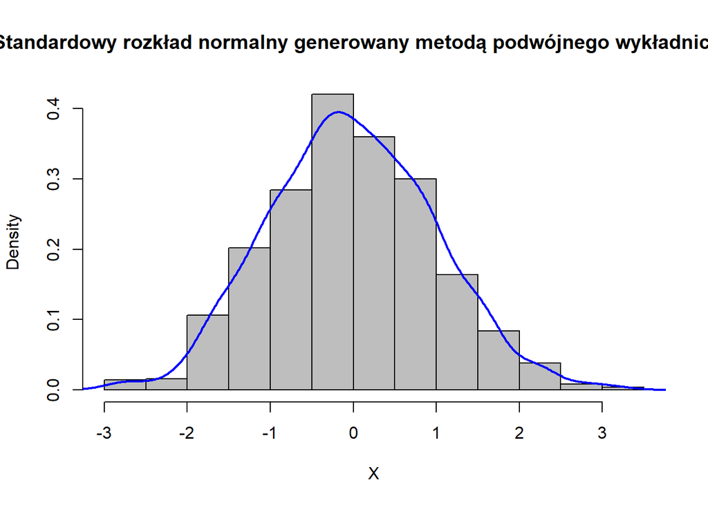

```
## [1] "Wartości teoretyczne:"
## [1] "Średnia:  0 , Mediana:  0"
## [1] "Wariancja:  1 , STD:  1"
## [1] "Wartości wygenerowane:"
## [1] "Średnia:  -0.0156952154086693 , Mediana:  -0.0471129270244924"
## [1] "Wariancja:  0.985879065255587 , STD:  0.992914429976515"
```

```r
nor <- normal_double(N=1000, mode="implemented")
plot_and_check_normal(nor, title = "Standardowy rozkład normalny generowany metodą podwójnego wykładniczego")
```

Możemy zauważyć, że rzeczywiście przypomina on standardowy rozkład normalny. Co więcej, otrzymane statystyki opisowe nie odchylają się zbytnio od statystyk teoretycznych. Przyrównajmy go jeszcze do generatora wbudowanego.

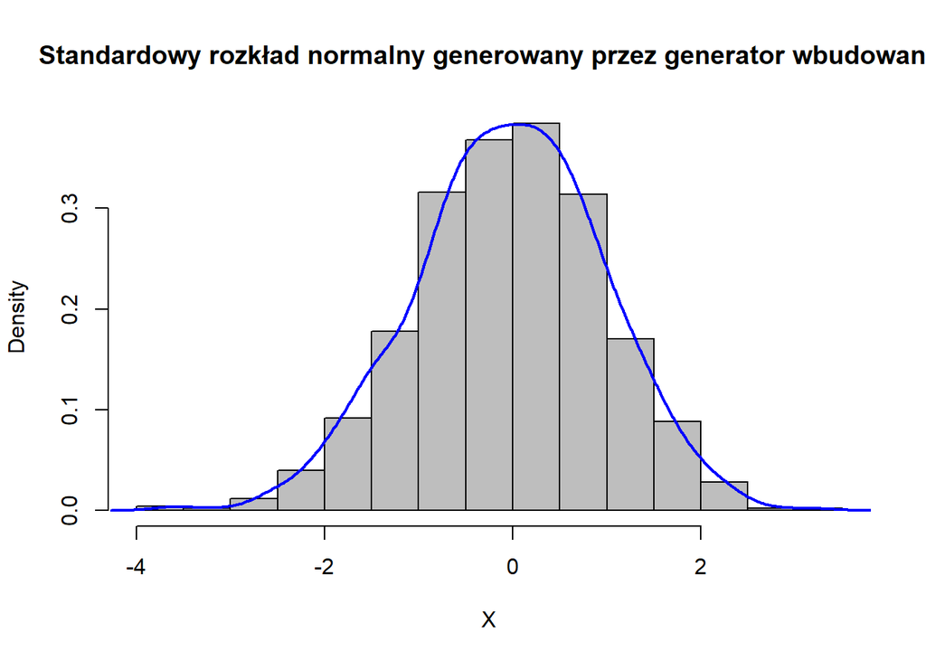

```
## [1] "Wartości teoretyczne:"
## [1] "Średnia:  0 , Mediana:  0"
## [1] "Wariancja:  1 , STD:  1"
## [1] "Wartości wygenerowane:"
## [1] "Średnia:  -0.0402120890812848 , Mediana:  -0.0115935142353226"
## [1] "Wariancja:  0.996580607379379 , STD:  0.998288839654826"
```

```r
nor <- rnorm(n=1000)
plot_and_check_normal(nor, title = "Standardowy rozkład normalny generowany przez generator wbudowany")
```

```r
normal_box <- function(N,m=valid[1], a=valid[2], c=valid[3], x=valid[4], mode="self"){
  if ((check_assumptions(m,a,c) == 'Założenia spełnione!' & mode == "self") | mode != "self"){
    X <- c()
    i <- 0
    while(length(X) < N){
      i <- i+1
      if (mode=="self"){
        U <- lcgen(3,m,a,c,x+i)
      } else{
        U <- runif(3)
      }
      U1 <- U[2]
      U2 <- U[3]
      R <- -2*log(U1)
      V <- 2*pi*U2

      Z1 <- sqrt(R)*cos(V)
      Z2 <- sqrt(R)*sin(V)


      X <- append(X,c(Z1,Z2))
    }
    return(X)
    }else{
      print("Wartości dla założeń nieprawidłowe!")
      return(0)
    }
  }
```

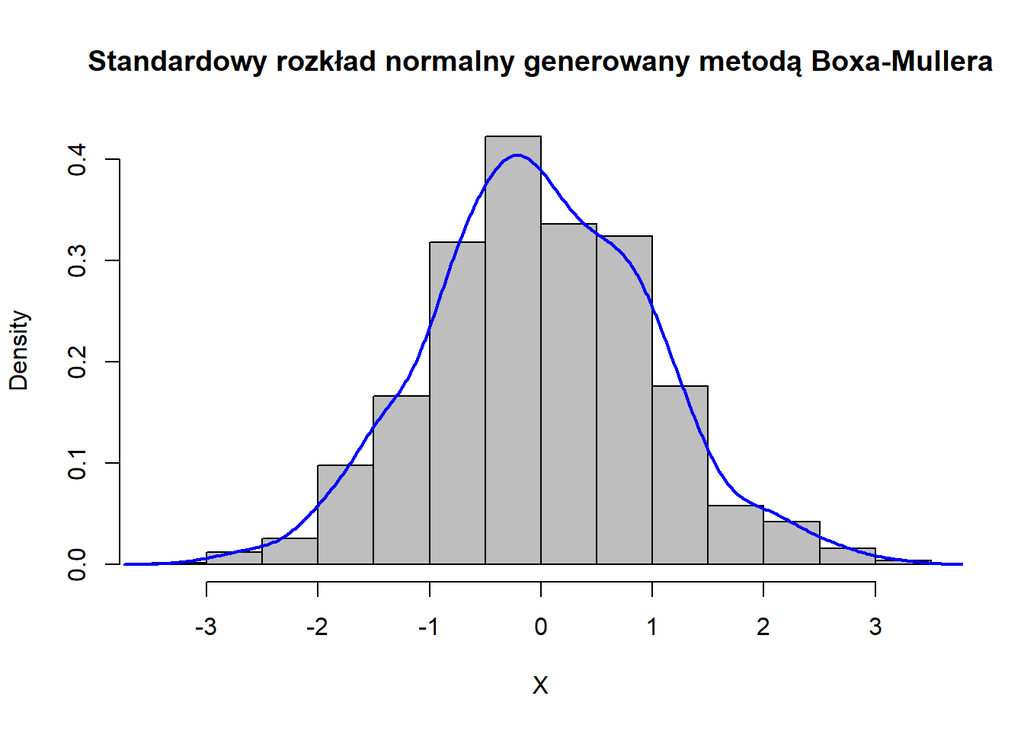

```
## [1] "Wartości teoretyczne:"
## [1] "Średnia:  0 , Mediana:  0"
## [1] "Wariancja:  1 , STD:  1"
## [1] "Wartości wygenerowane:"
## [1] "Średnia:  -0.0053562405723604 , Mediana:  -0.0475243084050788"
## [1] "Wariancja:  1.00414535177555 , STD:  1.0020705323357"
```

```r
box <- normal_box(N=1000, mode="implemented")
plot_and_check_normal(box, title = "Standardowy rozkład normalny generowany metodą Boxa-Mullera")
```

Jak widzimy, wartości również są całkiem przyzwoite, ale już niewiele gorsze (względem statystyk opisowych) od generatora wbudowanego. Wizualnie możemy zauważyć w jakim stopniu algorytm ten przybliża standardowy rozkład normalny. Tym sposobem zaimplementowaliśmy generator liczb pseudolosowych ze standardowego rozkładu normalnego przy użyciu dwóch metod - metody podwójnej wykładniczej oraz Boxa-Mullera. Naszym kolejnym i ostatnim krokiem przy generatorach liczb pseudolosowych będzie generator z rozkładu Poissona.